# R: Differential test functioning statistics

| DTF {mirt} | R Documentation |
| --- | --- |

## Differential test functioning statistics

### Description

Function performs various omnibus differential test functioning procedures on an object estimated with `multipleGroup()`. If the latent means/covariances are suspected to differ then the input object should contain a set of 'anchor' items to ensure that only differential test features are being detected rather than group differences. Returns signed (average area above and below) and unsigned (total area) statistics, with descriptives such as the percent average bias between group total scores for each statistic. If a grid of Theta values is passed, these can be evaluated as well to determine specific DTF location effects. For best results, the baseline model should contain a set of 'anchor' items and have freely estimated hyper-parameters in the focal groups. See `DIF` for details.

### Usage

```r
DTF(
  mod,
  draws = NULL,
  CI = 0.95,
  npts = 1000,
  theta_lim = c(-6, 6),
  Theta_nodes = NULL,
  plot = "none",
  auto.key = list(space = "right", points = FALSE, lines = TRUE),
  ...
)
```

### Arguments

[output not shown]

### Author(s)

Phil Chalmers rphilip.chalmers@gmail.com

### References

Chalmers, R., P. (2012). mirt: A Multidimensional Item Response Theory Package for the R Environment. *Journal of Statistical Software, 48*(6), 1-29. [doi:10.18637/jss.v048.i06](https://doi.org/10.18637/jss.v048.i06)

Chalmers, R. P., Counsell, A., and Flora, D. B. (2016). It might not make a big DIF: Improved Differential Test Functioning statistics that account for sampling variability. *Educational and Psychological Measurement, 76*, 114-140. [doi:10.1177/0013164415584576](https://doi.org/10.1177/0013164415584576)

### See Also

`multipleGroup`, `DIF`

### Examples

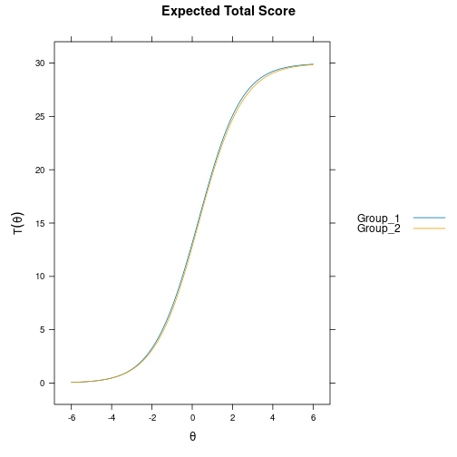

```r
## No test:
set.seed(1234)
n <- 30
N <- 500

# only first 5 items as anchors
model <- 'F = 1-30
          CONSTRAINB = (1-5, a1), (1-5, d)'

a <- matrix(1, n)
d <- matrix(rnorm(n), n)
group <- c(rep('Group_1', N), rep('Group_2', N))

## -------------
# groups completely equal
dat1 <- simdata(a, d, N, itemtype = '2PL')
dat2 <- simdata(a, d, N, itemtype = '2PL')
dat <- rbind(dat1, dat2)
mod <- multipleGroup(dat, model, group=group, SE=TRUE,
                     invariance=c('free_means', 'free_var'))
plot(mod)
```

```r
DTF(mod)
```

```
##    sDTF.score sDTF(%).score    uDTF.score uDTF(%).score
##     0.1743555     0.5811850     0.1770510     0.5901699
```

```r
if(interactive()) mirtCluster()
DTF(mod, draws = 1000) #95% C.I. for sDTF containing 0. uDTF is very small
```

```
## $observed
##    sDTF.score sDTF(%).score    uDTF.score uDTF(%).score
##     0.1743555     0.5811850     0.1770510     0.5901699
##
## $CIs
##         sDTF.score sDTF(%).score uDTF.score uDTF(%).score
## CI_97.5  0.4867914     1.6226381 0.78947666     2.6315889
## CI_2.5  -0.1432519    -0.4775062 0.09276249     0.3092083
##
## $tests
## P(sDTF.score = 0)
##         0.2790172
```

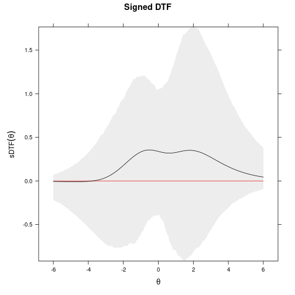

```r
DTF(mod, draws = 1000, plot='sDTF') #sDTF 95% C.I.'s across Theta always include 0
```

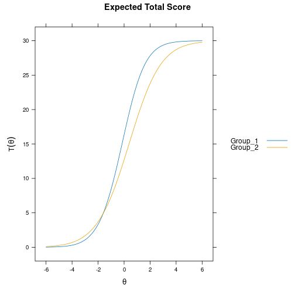

```r
## -------------
## random slopes and intercepts for 15 items, and latent mean difference
##    (no systematic DTF should exist, but DIF will be present)
set.seed(1234)
dat1 <- simdata(a, d, N, itemtype = '2PL', mu=.50, sigma=matrix(1.5))
dat2 <- simdata(a + c(numeric(15), runif(n-15, -.2, .2)),
                d + c(numeric(15), runif(n-15, -.5, .5)), N, itemtype = '2PL')
dat <- rbind(dat1, dat2)
mod1 <- multipleGroup(dat, 1, group=group)
plot(mod1) #does not account for group differences! Need anchors
```

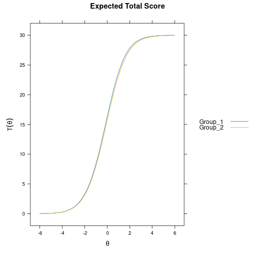

```r
mod2 <- multipleGroup(dat, model, group=group, SE=TRUE,
                      invariance=c('free_means', 'free_var'))
plot(mod2)
```

```r
# significant DIF in multiple items....
# DIF(mod2, which.par=c('a1', 'd'), items2test=16:30)
DTF(mod2)
```

```
##    sDTF.score sDTF(%).score    uDTF.score uDTF(%).score
##     0.1937625     0.6458750     0.1944299     0.6480997
```

```r
DTF(mod2, draws=1000) #non-sig DTF due to item cancellation
```

```
## $observed
##    sDTF.score sDTF(%).score    uDTF.score uDTF(%).score
##     0.1937625     0.6458750     0.1944299     0.6480997
##
## $CIs
##          sDTF.score sDTF(%).score uDTF.score uDTF(%).score
## CI_97.5  0.48660235     1.6220078 0.68524433     2.2841478
## CI_2.5  -0.05854047    -0.1951349 0.08193342     0.2731114
##
## $tests
## P(sDTF.score = 0)
##         0.1616771
```

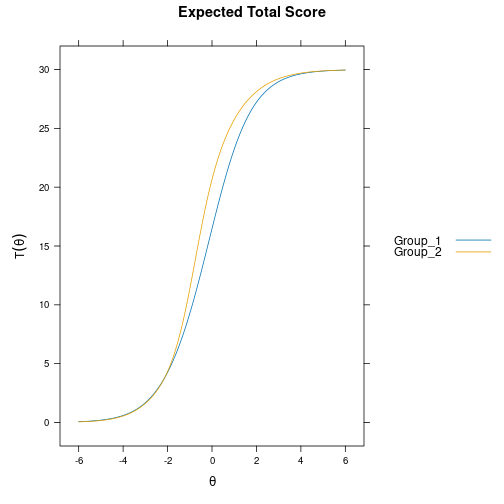

```r
## -------------
## systematic differing slopes and intercepts (clear DTF)
dat1 <- simdata(a, d, N, itemtype = '2PL', mu=.50, sigma=matrix(1.5))
dat2 <- simdata(a + c(numeric(15), rnorm(n-15, 1, .25)), d + c(numeric(15), rnorm(n-15, 1, .5)),
                N, itemtype = '2PL')
dat <- rbind(dat1, dat2)
mod3 <- multipleGroup(dat, model, group=group, SE=TRUE,
                      invariance=c('free_means', 'free_var'))
plot(mod3) #visable DTF happening
```

```r
# DIF(mod3, c('a1', 'd'), items2test=16:30)
DTF(mod3) #unsigned bias. Signed bias indicates group 2 scores generally higher on average
```

```
##    sDTF.score sDTF(%).score    uDTF.score uDTF(%).score
##    -0.8273273    -2.7577575     0.8537653     2.8458845
```

```r
DTF(mod3, draws=1000)
```

```
## $observed
##    sDTF.score sDTF(%).score    uDTF.score uDTF(%).score
##    -0.8273273    -2.7577575     0.8537653     2.8458845
##
## $CIs
##         sDTF.score sDTF(%).score uDTF.score uDTF(%).score
## CI_97.5  -0.493314     -1.644380  1.2303246      4.101082
## CI_2.5   -1.204117     -4.013725  0.6547475      2.182492
##
## $tests
## P(sDTF.score = 0)
##      2.622696e-06
```

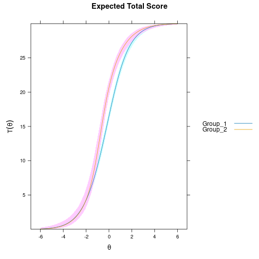

```r
DTF(mod3, draws=1000, plot='func')
```

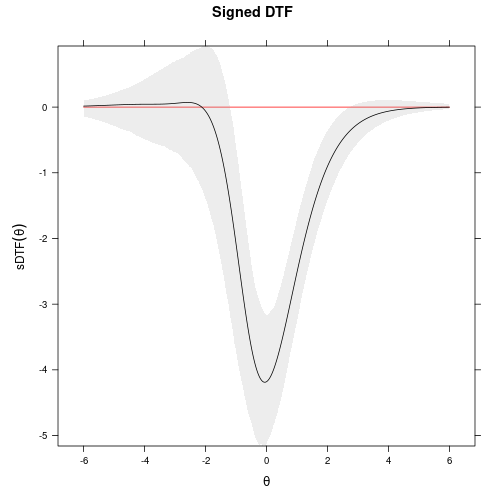

```r
DTF(mod3, draws=1000, plot='sDTF') #multiple DTF areas along Theta
```

```r
# evaluate specific values for sDTF
Theta_nodes <- matrix(seq(-6,6,length.out = 100))
sDTF <- DTF(mod3, Theta_nodes=Theta_nodes)
head(sDTF)
```

```
##             Theta       sDTF
## score.1 -6.000000 0.01508684
## score.2 -5.878788 0.01674974
## score.3 -5.757576 0.01853663
## score.4 -5.636364 0.02044213
## score.5 -5.515152 0.02245627
## score.6 -5.393939 0.02456352
```

```r
sDTF <- DTF(mod3, Theta_nodes=Theta_nodes, draws=100)
head(sDTF)
```

```
##             Theta       sDTF   CI_97.5     CI_2.5
## score.1 -6.000000 0.01508684 0.0944013 -0.1452826
## score.2 -5.878788 0.01674974 0.1012634 -0.1598883
## score.3 -5.757576 0.01853663 0.1115393 -0.1755821
## score.4 -5.636364 0.02044213 0.1231564 -0.1923808
## score.5 -5.515152 0.02245627 0.1357989 -0.2081907
## score.6 -5.393939 0.02456352 0.1495148 -0.2246265
```

```r
## End(No test)
```

[Package *mirt* version 1.43 Index]